# Project 1

(Simi Im, 730265758)

## 1.

```r
library(tidyverse)
```

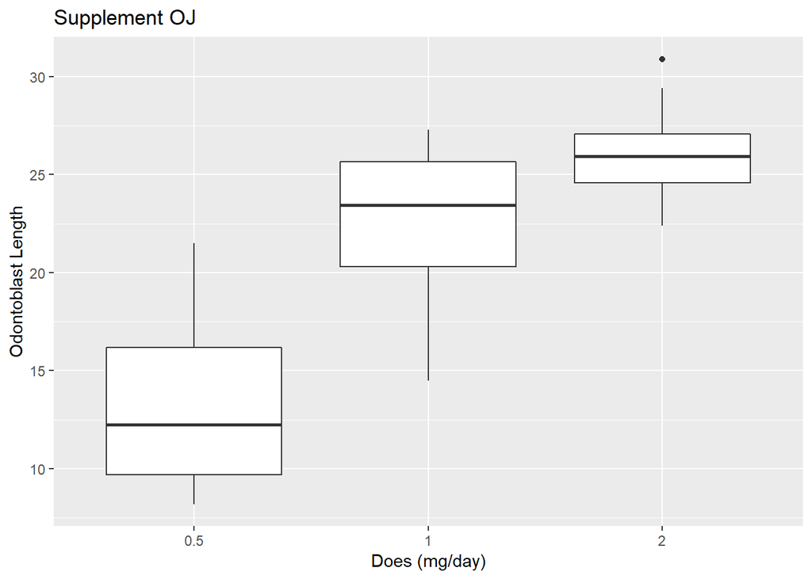

```r
data(ToothGrowth)
tooth <- as_tibble(ToothGrowth)

# graph #
tooth %>%
  filter(supp=='OJ') %>%
  ggplot() +
    geom_boxplot(mapping = aes(x=as.factor(dose), y=len)) +
    ggtitle('Supplement OJ') +
    xlab('Does (mg/day)') +
    ylab('Odontoblast Length')
```

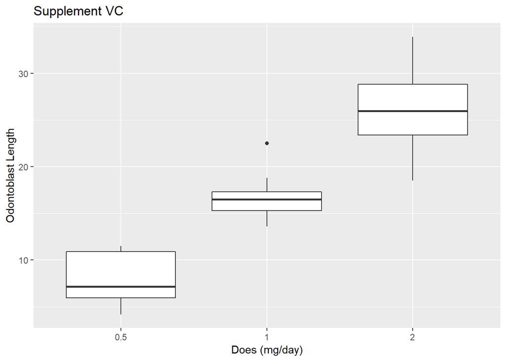

```r
tooth %>%
  filter(supp=='VC') %>%
  ggplot() +
    geom_boxplot(mapping = aes(x=as.factor(dose), y=len)) +
    ggtitle('Supplement VC') +
    xlab('Does (mg/day)') +
    ylab('Odontoblast Length')
```

```r
# summary #
 (conclude <- tooth %>%
  group_by(supp,dose) %>%
  mutate(med=median(len), rang=max(len)-min(len)) %>%
  distinct(med, rang))
```

```
## # A tibble: 6 x 4
## # Groups:   supp, dose [6]
##   supp   dose   med  rang
##   <fct> <dbl> <dbl> <dbl>
## 1 VC      0.5  7.15   7.3
## 2 VC      1   16.5    8.9
## 3 VC      2   26.0   15.4
## 4 OJ      0.5 12.2   13.3
## 5 OJ      1   23.5   12.8
## 6 OJ      2   26.0    8.5
```

The above figures are derived using the “ToothGrowth” data set in R, which is provided from “C. I. Bliss (1952). The Statistics of Bioassay. Academic Press.” This data set stores the length of odontoblasts (cells responsible for tooth growth) in 60 guinea pigs. Each guinea pigs received either 0.5, 1, or 2 mg/day of vitamin C through orange juice or ascorbic acid. For both vitamin C delivery methods, we can see from the boxplots that having higher dose of vitamin C per day resulted in longer odontoblasts.

In the future, it would be interesting to see if even higher level of vitamin C dosage helps odontoblasts growth, and if this vitamin C supplement promotes odontoblasts growth for different animals.

## 2.

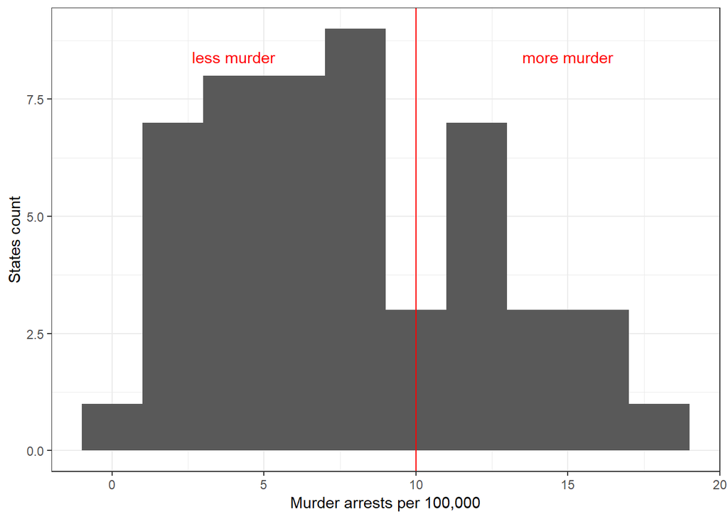

```r
data(USArrests)
arrest <- as_tibble(USArrests)

# graph & summary #
arrest %>%
  ggplot() +
    geom_histogram(mapping = aes(x=Murder), binwidth = 2) +
    geom_vline(xintercept = 10, color='red') +
    annotate('text', label='less murder', x=4, y=8.4, color='red') +
    annotate('text', label='more murder', x=15, y=8.4, color='red') +
    xlab('Murder arrests per 100,000') +
    ylab('States count')+
    theme_bw()
```

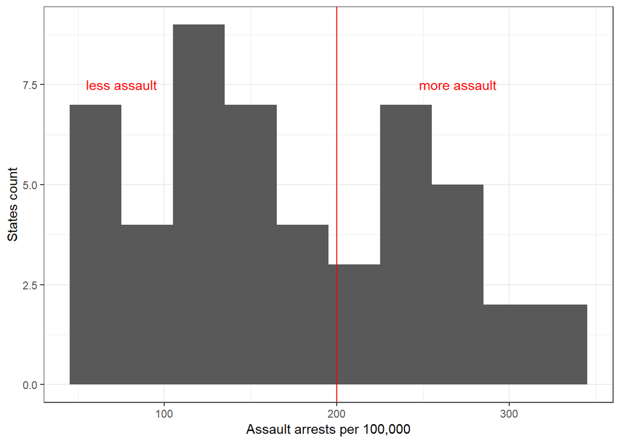

```r
m.less <- arrest %>%
  filter(Murder <= 10) %>%  mutate(mean.less=mean(Murder)) %>% select(mean.less) %>% unique()
m.more <- arrest %>%
  filter(Murder > 10) %>%  mutate(mean.more=mean(Murder)) %>% select(mean.more) %>% unique()

less.m <- arrest %>% filter(Murder <= 10) %>% mutate(mean.upop=mean(UrbanPop)) %>% select(mean.upop) %>% unique()
more.m <- arrest %>% filter(Murder > 10) %>% mutate(mean.upop=mean(UrbanPop)) %>% select(mean.upop) %>% unique()

arrest %>%
  ggplot() +
    geom_histogram(mapping = aes(x=Assault), binwidth = 30) +
    geom_vline(xintercept = 200, color='red') +
    annotate('text', label='less assault', x=75, y=7.5, color='red') +
    annotate('text', label='more assault', x=270, y=7.5, color='red') +
    xlab('Assault arrests per 100,000') +
    ylab('States count')+
    theme_bw()
```

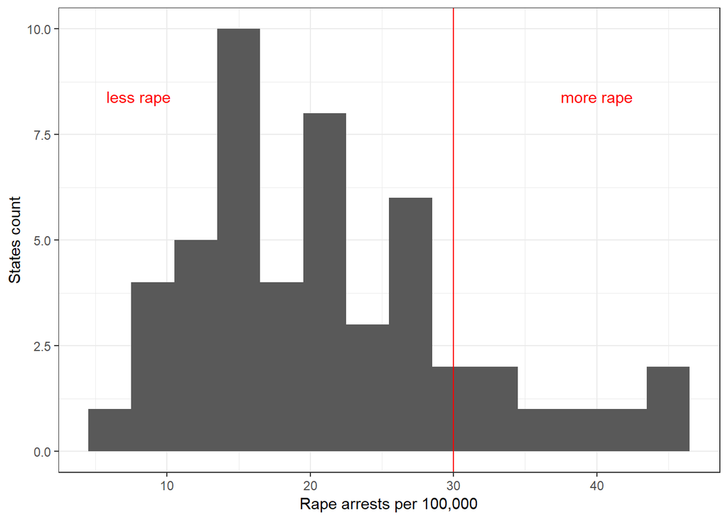

```r
a.less <- arrest %>%
  filter(Assault <= 200) %>%  mutate(mean.less=mean(Assault)) %>% select(mean.less) %>% unique()
a.more <- arrest %>%
  filter(Assault > 200) %>%  mutate(mean.more=mean(Assault)) %>% select(mean.more) %>% unique()

less.a <- arrest %>% filter(Assault <= 200) %>% mutate(mean.upop=mean(UrbanPop)) %>% select(mean.upop) %>% unique()
more.a <- arrest %>% filter(Assault > 200) %>% mutate(mean.upop=mean(UrbanPop)) %>% select(mean.upop) %>% unique()

arrest %>%
  ggplot() +
    geom_histogram(mapping = aes(x=Rape), binwidth = 3) +
    geom_vline(xintercept = 30, color='red') +
    annotate('text', label='less rape', x=8, y=8.4, color='red') +
    annotate('text', label='more rape', x=40, y=8.4, color='red') +
    xlab('Rape arrests per 100,000') +
    ylab('States count')+
    theme_bw()
```

```r
r.less <- arrest %>%
  filter(Rape <= 30) %>%  mutate(mean.less=mean(Rape)) %>% select(mean.less) %>% unique()
r.more <- arrest %>%
  filter(Rape > 30) %>%  mutate(mean.more=mean(Rape)) %>% select(mean.more) %>% unique()

less.r <- arrest %>% filter(Rape <= 30) %>% mutate(mean.upop=mean(UrbanPop)) %>% select(mean.upop) %>% unique()
more.r <- arrest %>% filter(Rape > 30) %>% mutate(mean.upop=mean(UrbanPop)) %>% select(mean.upop) %>% unique()
```

The above figures are derived using the “USArrests” data set in R, which is provided from “World Almanac and Book of facts 1975.” for crime rates and “Statistical Abstracts of the United States 1975, p.20,” for urban rates. This data set stores the number of murder, assault, and rapes per 100,000 for each 50 states in the United States, along with the percent of urban population.

The histogram of murder arrests, assault arrests, and rape arrests seems that the states can be devided into two groups. Those with lower crime rates, and those with higher crime rates. The murder and assault histograms show bi-modal shape, and the rape histogram shows a long right tail distribution which I will seperate out from the “less” rape arrest rate. For murder arrests, the “less” group has 5.43 murder arrests per 100,000 and the “more” group has 13.29 murder arrests per 100,000. For assault arrests, the “less” group has 114.87 murder arrests per 100,000 and the “more” group has 261.95 murder arrests per 100,000. For assault arrests, the “less” group has 18.14 murder arrests per 100,000 and the “more” group has 37.49 murder arrests per 100,000.

In the future, it would be interesting to see if the number of police officers around the urban area has an affect to the crime rates.

## 3.

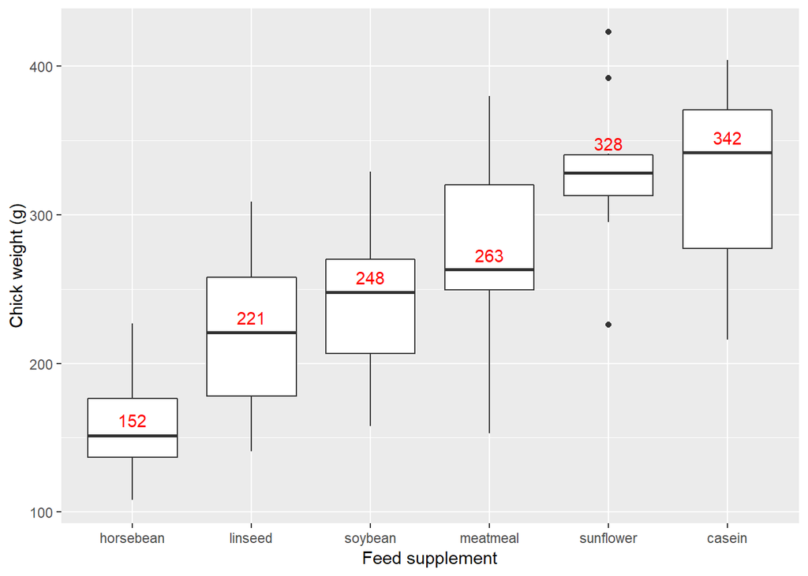

```r
data(chickwts)
chick <- as_tibble(chickwts)

# graph #
chick %>%
  ggplot() +
    geom_boxplot(mapping = aes(x=reorder(feed,weight,FUN=median), y=weight)) +
    xlab('Feed supplement') +
    ylab('Chick weight (g)') +
    annotate('text', label='152', x=1, y=162, color='red') +
    annotate('text', label='221', x=2, y=231, color='red') +
    annotate('text', label='248', x=3, y=258, color='red') +
    annotate('text', label='263', x=4, y=273, color='red') +
    annotate('text', label='328', x=5, y=348, color='red') +
    annotate('text', label='342', x=6, y=352, color='red')
```

```r
# summary #
med <- chick %>%
  group_by(feed) %>%
  mutate(med=median(weight)) %>% select(feed,med) %>% unique()
```

The above boxplots are derived using the “chickwts” data set in R, which is provided from “Anonymous (1948) Biometrika, 35, 214.” This data set stores the weight of chicks after six weeks, in grams. The chicks were randomly allocated into six groups, each receiving different feed supplements which were: casein, horsebean, linseed, meatmeal, soybean, and sunflower.

Each boxplots has the median values of weight written above the median lines. Looking at the median values, we can see that in the order of horsebean, linseed, soybean, meatmeal, sunflower, and casein, the chicks are heavier.

In the future, it would be interesting to see if this trend of chick growth is consistent with different types of chicks.

## 4.

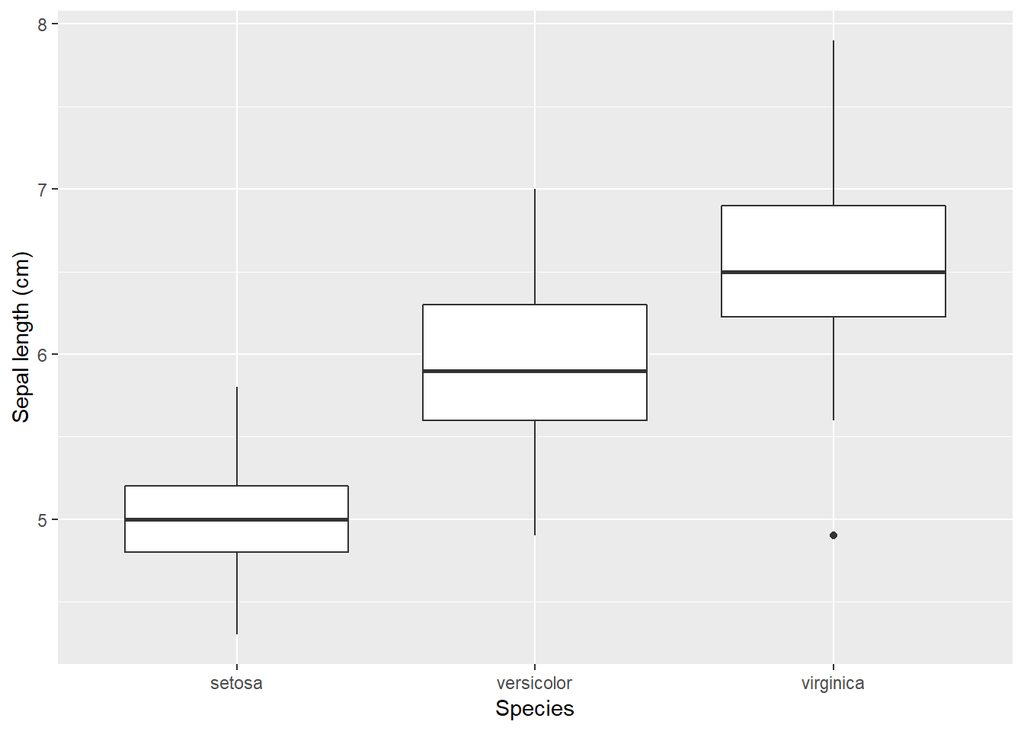

```r
data(iris)
iris <- as_tibble(iris)

# graph #
iris %>%
  ggplot() +
    geom_boxplot(mapping = aes(x=Species, y=Sepal.Length)) +
    ylab('Sepal length (cm)')
```

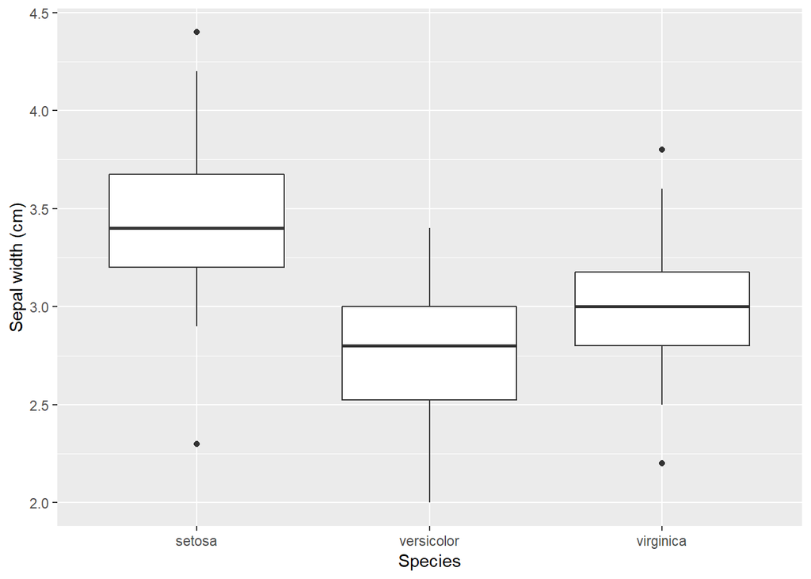

```r
iris %>%
  ggplot() +
    geom_boxplot(mapping = aes(x=Species, y=Sepal.Width)) +
    ylab('Sepal width (cm)')
```

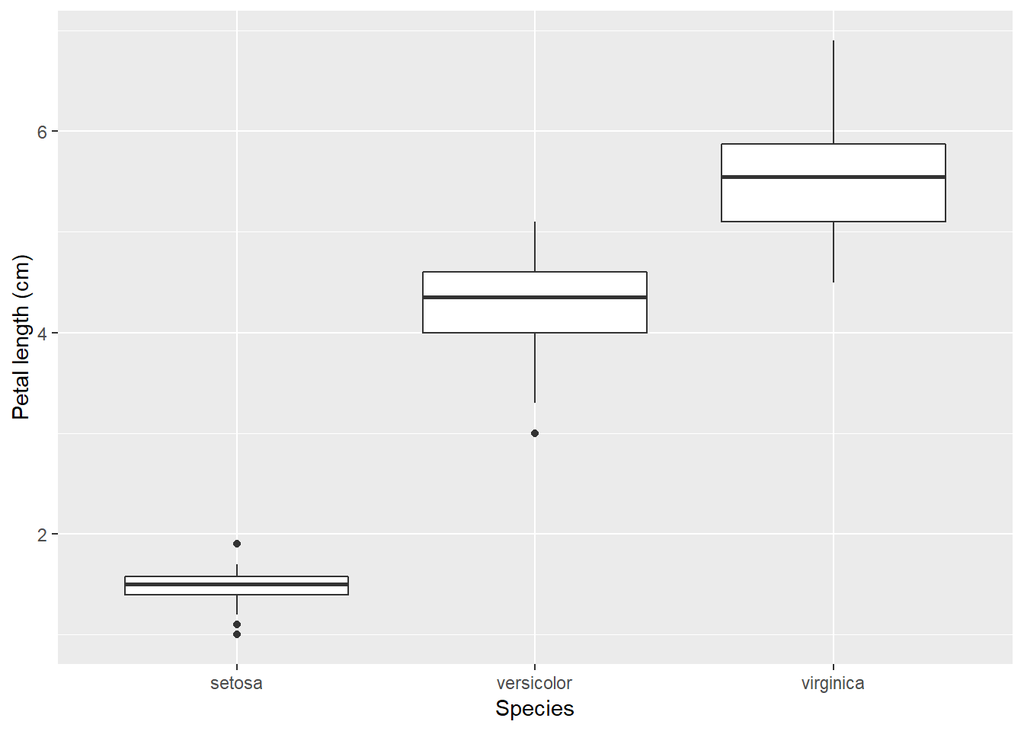

```r
iris %>%
  ggplot() +
    geom_boxplot(mapping = aes(x=Species, y=Petal.Length)) +
    ylab('Petal length (cm)')
```

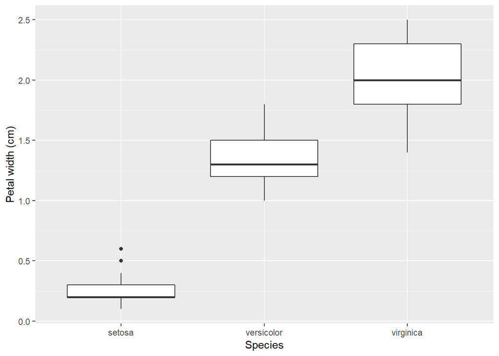

```r
iris %>%
  ggplot() +
    geom_boxplot(mapping = aes(x=Species, y=Petal.Width)) +
    ylab('Petal width (cm)')
```

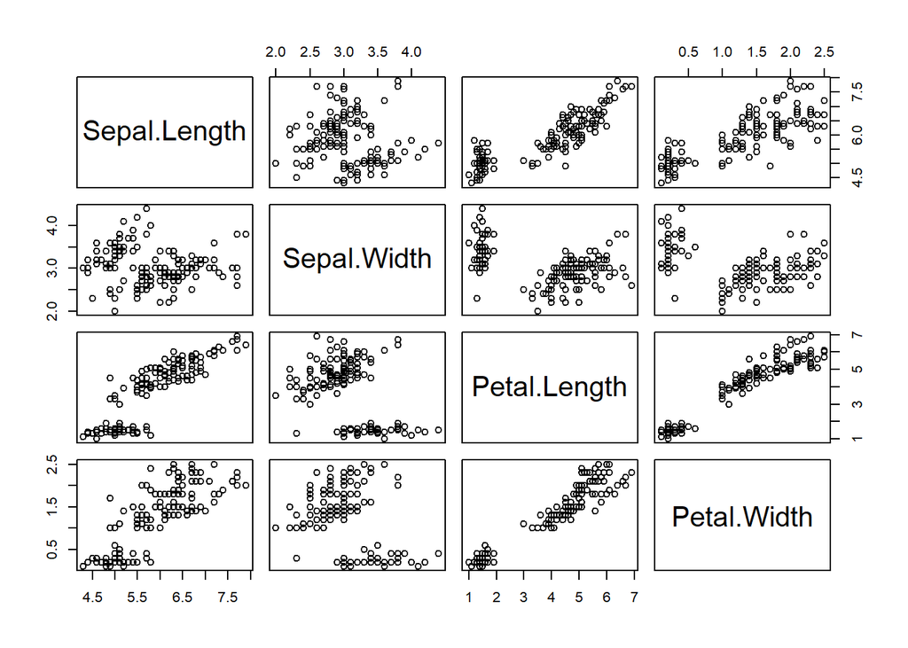

```r
pairs(iris[1:4])
```

```r
# summary #
(iris.med <- iris %>%
  group_by(Species) %>%
  mutate(med.sl=median(Sepal.Length), med.sw=median(Sepal.Width), med.pl=median(Petal.Length), med.pw=median(Petal.Width)) %>%
  select(Species, med.sl, med.sw, med.pl, med.pw) %>% unique())
```

```
## # A tibble: 3 x 5
## # Groups:   Species [3]
##   Species    med.sl med.sw med.pl med.pw
##   <fct>       <dbl>  <dbl>  <dbl>  <dbl>
## 1 setosa        5      3.4   1.5     0.2
## 2 versicolor    5.9    2.8   4.35    1.3
## 3 virginica     6.5    3     5.55    2
```

The above boxplots are derived using the “iris” data set in R, which is provided from “Fisher, R. A. (1936) The use of multiple measurements in taxonomic problems. Annals of Eugenics, 7, Part II, 179–188.” and “The irises of the Gaspe Peninsula, Bulletin of the American Iris Society, 59, 2–5.” It is obvious that in the order of setosa, versicolor, and virginica, the measurements of sepal length, petal length, and petal width gets larger. However, for the sepal width, setosa has the highest value. From the scatterplot matrix of each measurements, we can see that the scatterplots associated with sepal width doesn’t look linear. However, for a iris the petal size is what matters more than sepal size since petal is the visually attractive part of the flower. Therefore, this unpredicted behavior of sepal width is not a huge issue.

The median values for sepal length, sepal width, petal length, and petal width are setosa, 5, 3.4, 1.5, for setosa, versicolor, 5.9, 2.8, 4.35 for versicolor, and virginica, 6.5, 3, 5.55 for virginica, respectively. If we want a iris where the petal is emphasized, virginica seems to be the best iris species.